# Research project

Anastasia Kucheruk, Olena Hnyp, Kateryna Shvahuliak

2023-12-16

## Research project:

### Analysis of delivery time and its dependence on various factors

Data set: https://www.kaggle.com/datasets/rajatkumar30/food-delivery-time/code

### Libraries which we use in research

```r
library(ggplot2)
library(dplyr)
```

## Read data

In our original data we had columns ID and coordinates (latitude, longitude of restaurants and delivery location). We deleted these columns, and instead of the coordinates, we inserted a column with the distance using Python. Also, we added column Speed for future calculations.

```r
delivery <- read.csv("new_deliverytime.csv")

#add column speed (speed (km/hours) = ditance (km)/ (time (min)/60))
delivery$Speed <- delivery$Distance * 60 / delivery$Time_taken.min.
```

## Classification of data

We decided to divide people into two groups: under 30 and over 30. We want to test whether age somehow influences delivery time. Also, we will be considering only delivery in the range of 30 km because mostly food is not delivered further than that.

```r
sorted_distance <- delivery[order(delivery$Distance), ]
under_30 <- sorted_distance[sorted_distance$Delivery_person_Age < 30 & sorted_distance$Distance < 30, ]
over_30 <- sorted_distance[sorted_distance$Delivery_person_Age >= 30 & sorted_distance$Distance < 30, ]
```

## How does vehicle type influence delivery speed?

### Let`s analyze how the vehicle delivery person is using influences delivery time.

Split by type of vehicle:

```r
vehicle_type_under_30 <- split(under_30, under_30$Type_of_vehicle)
motorcycle_under_30 <- vehicle_type_under_30$motorcycle
bicycle_under_30 <- vehicle_type_under_30$bicycle
scooter_under_30 <- vehicle_type_under_30$scooter
electric_scooter_under_30 <- vehicle_type_under_30$electric_scooter
```

```r
vehicle_type_over_30 <- split(over_30, over_30$Type_of_vehicle)
motorcycle_over_30 <- vehicle_type_over_30$motorcycle
bicycle_over_30 <- vehicle_type_over_30$bicycle
scooter_over_30 <- vehicle_type_over_30$scooter
electric_scooter_over_30 <- vehicle_type_over_30$electric_scooter
```

Compare means of speed of people under 30 and over 30 who deliver by motorcycle:

```r
mean_motorcycle_under_30 <- mean(motorcycle_under_30$Speed)
cat("Mean delivery speed of people under 30 on motorcycle:", mean_motorcycle_under_30, "\n")
```

```
## Mean delivery speed of people under 30 on motorcycle: 25.67256
```

```r
mean_motorcycle_over_30 <- mean(motorcycle_over_30$Speed)
cat("Mean delivery speed of people over 30 on motorcycle:", mean_motorcycle_over_30)
```

```
## Mean delivery speed of people over 30 on motorcycle: 19.35993
```

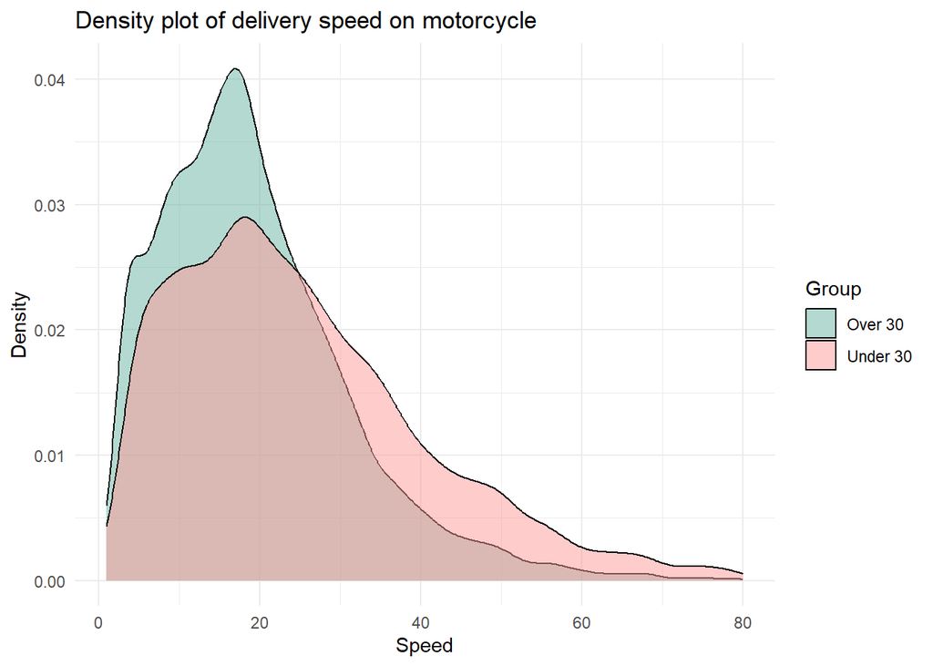

```r
all_motorcycle_data <- bind_rows(
  mutate(motorcycle_under_30, Group = "Under 30"),
  mutate(motorcycle_over_30, Group = "Over 30")
)

all_motorcycle_data %>%
  ggplot(aes(x = Speed, fill = Group)) +
  geom_density(alpha = 0.5) +
  labs(title = "Density plot of delivery speed on motorcycle", x = "Speed", y = "Density") +
  theme_minimal() +
  xlim(1, 80) +
  scale_fill_manual(values = c("#69b3a2", "#FF9999"))
```

Compare means of speed of people under 30 and over 30 who deliver by bicycle:

```r
mean_bicycle_under_30 <- mean(bicycle_under_30$Speed)
cat("Mean delivery speed of people under 30 on bicycle:", mean_bicycle_under_30, "\n")
```

```
## Mean delivery speed of people under 30 on bicycle: 20.70248
```

```r
mean_bicycle_over_30 <- mean(bicycle_over_30$Speed)
cat("Mean delivery speed of people over 30 on bicycle:", mean_bicycle_over_30)
```

```
## Mean delivery speed of people over 30 on bicycle: 10.0549
```

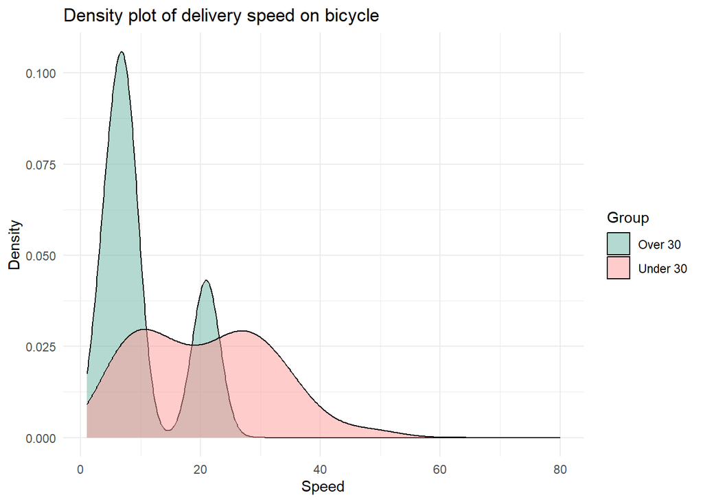

```r
all_bicycle_data <- bind_rows(
  mutate(bicycle_under_30, Group = "Under 30"),
  mutate(bicycle_over_30, Group = "Over 30")
)

all_bicycle_data %>%
  ggplot(aes(x = Speed, fill = Group)) +
  geom_density(alpha = 0.5) +
  labs(title = "Density plot of delivery speed on bicycle", x = "Speed", y = "Density") +
  theme_minimal() +
  xlim(1, 80) +
  scale_fill_manual(values = c("#69b3a2", "#FF9999"))
```

Compare means of speed of people under 30 and over 30 who deliver by scooter:

```r
mean_scooter_under_30 <- mean(scooter_under_30$Speed)
cat("Mean delivery speed of people under 30 on scooter:", mean_scooter_under_30, "\n")
```

```
## Mean delivery speed of people under 30 on scooter: 28.9358
```

```r
mean_scooter_over_30 <- mean(scooter_over_30$Speed)
cat("Mean delivery speed of people over 30 on scooter:", mean_scooter_over_30)
```

```
## Mean delivery speed of people over 30 on scooter: 22.04266
```

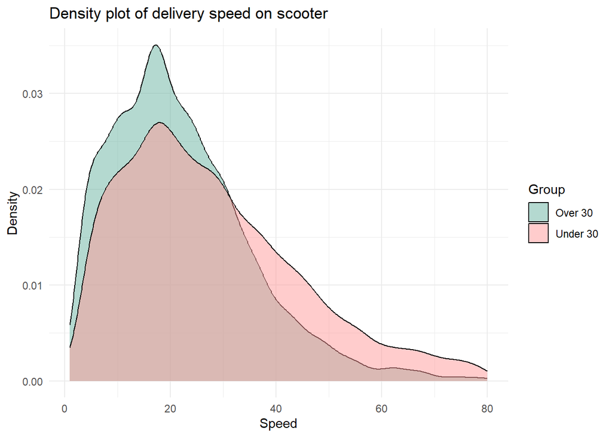

```r
all_scooter_data <- bind_rows(
  mutate(scooter_under_30, Group = "Under 30"),
  mutate(scooter_over_30, Group = "Over 30")
)

all_scooter_data %>%
  ggplot(aes(x = Speed, fill = Group)) +
  geom_density(alpha = 0.5) +
  labs(title = "Density plot of delivery speed on scooter", x = "Speed", y = "Density") +
  theme_minimal() +
  xlim(1, 80) +
  scale_fill_manual(values = c("#69b3a2", "#FF9999"))
```

Compare means of speed of people under 30 and over 30 who deliver by electric scooter:

```r
mean_electric_scooter_under_30 <- mean(electric_scooter_under_30$Speed)
cat("Mean delivery speed of people under 30 on electric scooter:", mean_electric_scooter_under_30, "\n")
```

```
## Mean delivery speed of people under 30 on electric scooter: 29.25637
```

```r
mean_electric_scooter_over_30 <- mean(electric_scooter_over_30$Speed)
cat("Mean delivery speed of people over 30 on electric scooter:", mean_electric_scooter_over_30)
```

```
## Mean delivery speed of people over 30 on electric scooter: 21.74748
```

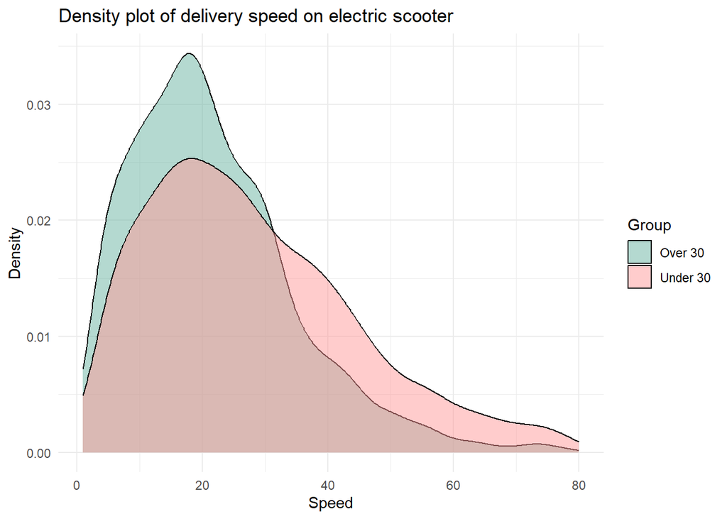

```r
all_electric_scooter_data <- bind_rows(
  mutate(electric_scooter_under_30, Group = "Under 30"),
  mutate(electric_scooter_over_30, Group = "Over 30")
)

all_electric_scooter_data %>%
  ggplot(aes(x = Speed, fill = Group)) +
  geom_density(alpha = 0.5) +
  labs(title = "Density plot of delivery speed on electric scooter", x = "Speed", y = "Density") +
  theme_minimal() +
  xlim(1, 80) +
  scale_fill_manual(values = c("#69b3a2", "#FF9999"))
```

We can see that the worst type of vehicle to deliver food is a bicycle. When we ride it, the speed is the lowest among the other vehicle types. We can also check if people under 30 drive some vehicles quicker than people over 30.

```r
if (mean_motorcycle_under_30 > mean_motorcycle_over_30) {
  cat("People under 30 deliver on motorcycle quicker than people over 30\n")
} else {
  cat("People over 30 deliver on motorcycle quicker than people under 30\n")
}
```

```
## People under 30 deliver on motorcycle quicker than people over 30
```

```r
if (mean_bicycle_under_30 > mean_bicycle_over_30) {
  cat("People under 30 deliver on bicycle quicker than people over 30\n")
} else {
  cat("People over 30 deliver on bicycle quicker than people under 30\n")
}
```

```
## People under 30 deliver on bicycle quicker than people over 30
```

```r
if (mean_scooter_under_30 > mean_scooter_over_30) {
  cat("People under 30 deliver on scooter quicker than people over 30\n")
} else {
  cat("People over 30 deliver on scooter quicker than people under 30\n")
}
```

```
## People under 30 deliver on scooter quicker than people over 30
```

```r
if (mean_electric_scooter_under_30 > mean_electric_scooter_over_30) {
  cat("People under 30 deliver on electric scooter quicker than people over 30")
} else {
  cat("People over 30 deliver on electric scooter quicker than people under 30")
}
```

```
## People under 30 deliver on electric scooter quicker than people over 30
```

So, we can conclude that no matter what vehicle type the delivery person is using, delivery is quicker if the person is under 30. But this testing is not enough to fire all delivery people over 30. Let`s keep testing!

## How does type of order influence delivery speed?

Split by type of order:

```r
order_type_under_30 <- split(under_30, under_30$Type_of_order)
meal_under_30 <- order_type_under_30$Meal
snack_under_30 <- order_type_under_30$Snack
buffet_under_30 <- order_type_under_30$Buffet
drink_under_30 <- order_type_under_30$Drink
```

```r
order_type_over_30 <- split(over_30, over_30$Type_of_order)
meal_over_30 <- order_type_over_30$Meal
snack_over_30 <- order_type_over_30$Snack
buffet_over_30 <- order_type_over_30$Buffet
drink_over_30 <- order_type_over_30$Drink
```

Compare means of speed of people under 30 and over 30 who deliver meal:

```r
mean_meal_under_30 <- mean(meal_under_30$Speed)
cat("Mean meal delivery speed of people under 30:", mean_meal_under_30, "\n")
```

```
## Mean meal delivery speed of people under 30: 26.97961
```

```r
mean_meal_over_30 <- mean(meal_over_30$Speed)
cat("Mean meal delivery speed of people over 30:", mean_meal_over_30)
```

```
## Mean meal delivery speed of people over 30: 20.14628
```

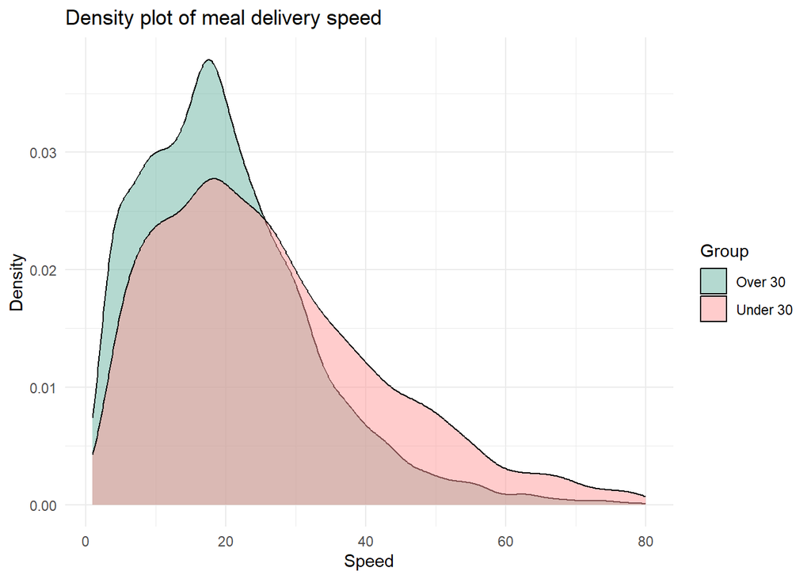

```r
all_meal_data <- bind_rows(
  mutate(meal_under_30, Group = "Under 30"),
  mutate(meal_over_30, Group = "Over 30")
)

all_meal_data %>%
  ggplot(aes(x = Speed, fill = Group)) +
  geom_density(alpha = 0.5) +
  labs(title = "Density plot of meal delivery speed", x = "Speed", y = "Density") +
  theme_minimal() +
  xlim(1, 80) +
  scale_fill_manual(values = c("#69b3a2", "#FF9999"))
```

Compare means of speed of people under 30 and over 30 who deliver snacks:

```r
mean_snack_under_30 <- mean(snack_under_30$Speed)
cat("Mean snack delivery speed of people under 30:", mean_snack_under_30, "\n")
```

```
## Mean snack delivery speed of people under 30: 27.18881
```

```r
mean_snack_over_30 <- mean(snack_over_30$Speed)
cat("Mean snack delivery speed of people over 30:", mean_snack_over_30)
```

```
## Mean snack delivery speed of people over 30: 20.60383
```

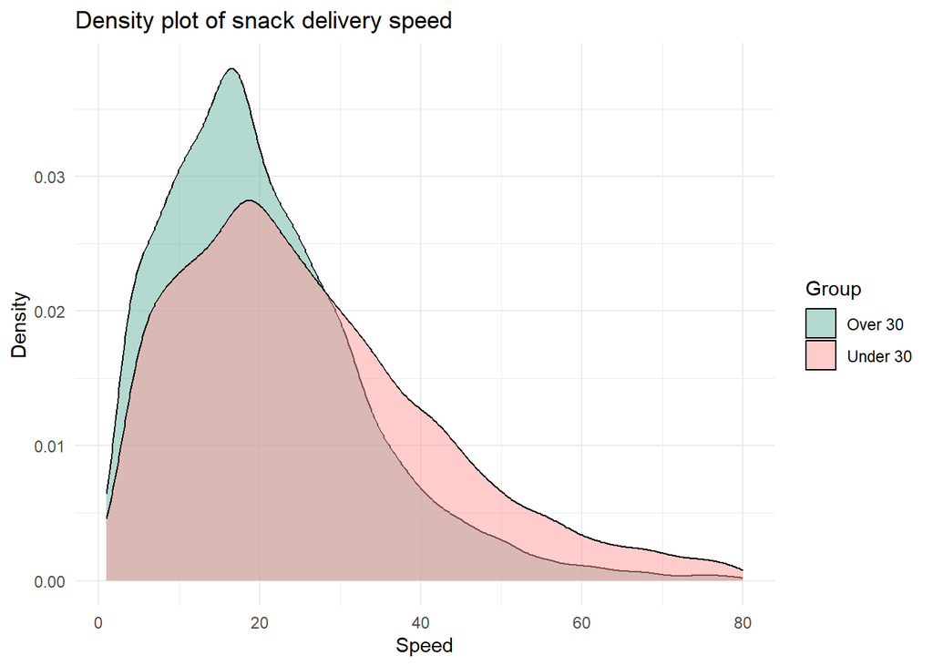

```r
all_snack_data <- bind_rows(
  mutate(snack_under_30, Group = "Under 30"),
  mutate(snack_over_30, Group = "Over 30")
)

all_snack_data %>%
  ggplot(aes(x = Speed, fill = Group)) +
  geom_density(alpha = 0.5) +
  labs(title = "Density plot of snack delivery speed", x = "Speed", y = "Density") +
  theme_minimal() +
  xlim(1, 80) +
  scale_fill_manual(values = c("#69b3a2", "#FF9999"))
```

Compare means of speed of people under 30 and over 30 who deliver buffet:

```r
mean_buffet_under_30 <- mean(buffet_under_30$Speed)
cat("Mean buffet delivery speed of people under 30:", mean_buffet_under_30, "\n")
```

```
## Mean buffet delivery speed of people under 30: 26.85614
```

```r
mean_buffet_over_30 <- mean(buffet_over_30$Speed)
cat("Mean buffet delivery speed of people over 30:", mean_buffet_over_30)
```

```
## Mean buffet delivery speed of people over 30: 20.62439
```

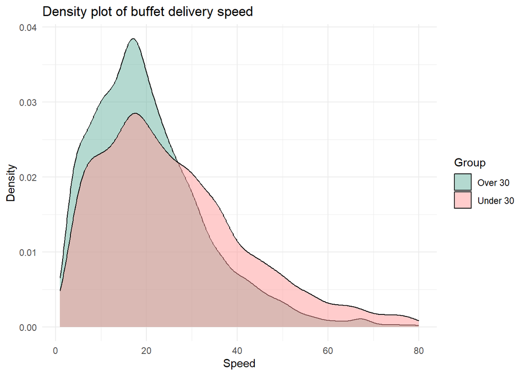

```r
all_buffet_data <- bind_rows(
  mutate(buffet_under_30, Group = "Under 30"),
  mutate(buffet_over_30, Group = "Over 30")
)

all_buffet_data %>%
  ggplot(aes(x = Speed, fill = Group)) +
  geom_density(alpha = 0.5) +
  labs(title = "Density plot of buffet delivery speed", x = "Speed", y = "Density") +
  theme_minimal() +
  xlim(1, 80) +
  scale_fill_manual(values = c("#69b3a2", "#FF9999"))
```

Compare means of speed of people under 30 and over 30 who deliver drinks:

```r
mean_drink_under_30 <- mean(drink_under_30$Speed)
cat("Mean drink delivery speed of people under 30:", mean_drink_under_30, "\n")
```

```
## Mean drink delivery speed of people under 30: 27.21294
```

```r
mean_drink_over_30 <- mean(drink_over_30$Speed)
cat("Mean drink delivery speed of people over 30:", mean_drink_over_30)
```

```
## Mean drink delivery speed of people over 30: 20.42429
```

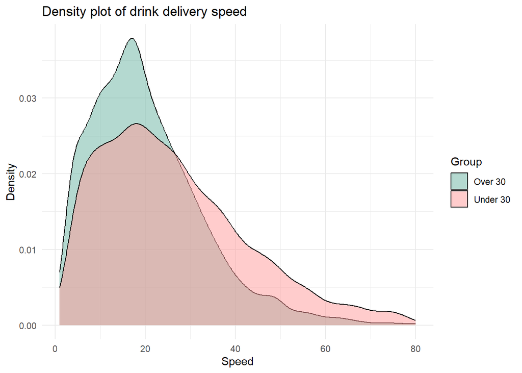

```r
all_drink_data <- bind_rows(
  mutate(drink_under_30, Group = "Under 30"),
  mutate(drink_over_30, Group = "Over 30")
)

all_drink_data %>%
  ggplot(aes(x = Speed, fill = Group)) +
  geom_density(alpha = 0.5) +
  labs(title = "Density plot of drink delivery speed", x = "Speed", y = "Density") +
  theme_minimal() +
  xlim(1, 80) +
  scale_fill_manual(values = c("#69b3a2", "#FF9999"))
```

Let’s consider who delivers food faster - people under 30 or over 30:

```r
if (mean_meal_under_30 > mean_meal_over_30) {
  cat("People under 30 deliver meals quicker than people over 30\n")
} else {
  cat("People over 30 deliver meals quicker than people under 30\n")
}
```

```
## People under 30 deliver meals quicker than people over 30
```

```r
if (mean_snack_under_30 > mean_snack_over_30) {
  cat("People under 30 deliver snacks quicker than people over 30\n")
} else {
  cat("People over 30 deliver snacks quicker than people under 30\n")
}
```

```
## People under 30 deliver snacks quicker than people over 30
```

```r
if (mean_buffet_under_30 > mean_buffet_over_30) {
  cat("People under 30 deliver buffet quicker than people over 30\n")
} else {
  cat("People over 30 deliver buffet quicker than people under 30\n")
}
```

```
## People under 30 deliver buffet quicker than people over 30
```

```r
if (mean_drink_under_30 > mean_drink_over_30) {
  cat("People under 30 deliver drinks scooter quicker than people over 30")
} else {
  cat("People over 30 deliver drinks scooter quicker than people under 30")
}
```

```
## People under 30 deliver drinks scooter quicker than people over 30
```

Again, we can see that people under 30 deliver different type of foods quicker than people over 30. But is the difference significant enough to fire delivery people over 30?

## Hypotheses testing

Let’s test whether delivery speed of people under 30 and over 30 has normal distribution. For this, we use Kolmogorov-Smirnov test:

```r
speed_under_30 <- under_30$Speed
speed_under_30_without_ties <- jitter(speed_under_30)
ks.test(speed_under_30_without_ties, "pnorm")
```

```
##
##  Asymptotic one-sample Kolmogorov-Smirnov test
##
## data:  speed_under_30_without_ties
## D = 0.99542, p-value < 2.2e-16
## alternative hypothesis: two-sided
```

```r
speed_over_30 <- over_30$Speed
speed_over_30_without_ties <- jitter(speed_over_30)
ks.test(speed_over_30_without_ties, "pnorm")
```

```
##
##  Asymptotic one-sample Kolmogorov-Smirnov test
##
## data:  speed_over_30_without_ties
## D = 0.99084, p-value < 2.2e-16
## alternative hypothesis: two-sided
```

As we can see, in both cases we reject the null hypothesis that distributions of speed are normal because p-value is less than significance level of 0.05. So, the results of the next tests will be approximate.

$$\text{Our hypotheses are:} \\
H_0: \mu_1 = \mu_2 \text{ vs } H_1: \mu_1 \neq \mu_2 \\
\text{ where } \mu_1 \text{ is the mean delivery speed of people under
30 } \\
\text { and } \mu_2 \text{ is the mean delivery speed of people over 30
}$$

Let`s use t-test to test the means because the variance is unknown:

```r
speed_under_30 <- under_30$Speed
speed_over_30 <- over_30$Speed
t_test_age <- t.test(speed_under_30, speed_over_30)
t_test_age
```

```
##
##  Welch Two Sample t-test
##
## data:  speed_under_30 and speed_over_30
## t = 45.833, df = 41773, p-value < 2.2e-16
## alternative hypothesis: true difference in means is not equal to 0
## 95 percent confidence interval:
##  6.329987 6.895572
## sample estimates:
## mean of x mean of y
##  27.06085  20.44807
```

Our p-value is smaller than 0.05 so we can reject the null hypothesis. Now we definitely can conclude that delivery people under 30 deliver food quicker than people over 30. And it doesn`t matter what vehicle they are using or what food they are delivering.

Also, we want to test whether meals are delivered longer than other types of food and whether snacks are delivered quicker.

```r
distance_less30 <- delivery[delivery$Distance < 30, ]
food_30 <- split(distance_less30, distance_less30$Type_of_order)
drinks <- food_30$`Drinks `
meal <- food_30$`Meal `
buffet <- food_30$`Buffet `
snacks <- food_30$`Snack `
```

$$\text{Our hypotheses are:} \\
H_0: \mu_1 = \mu_2 \text{ vs } H_1: \mu_1 \lt \mu_2 \\
\text{ where } \mu_1 \text{ is the mean delivery speed of meals } \\
\text { and } \mu_2 \text{ is the mean delivery speed of drinks
}$$

```r
meal_drink_t_test <- t.test(meal$Speed, drinks$Speed, "l")
meal_drink_t_test
```

```
##
##  Welch Two Sample t-test
##
## data:  meal$Speed and drinks$Speed
## t = -1.4982, df = 22523, p-value = 0.06705
## alternative hypothesis: true difference in means is less than 0
## 95 percent confidence interval:
##        -Inf 0.03083118
## sample estimates:
## mean of x mean of y
##  23.60998  23.92475
```

We can see that our p-value is greater than 0.05 so we will not reject the null hypothesis. It means that we can`t say that meals are delivered longer than drinks.

$$\text{Our hypotheses are:} \\
H_0: \mu_1 = \mu_2 \text{ vs } H_1: \mu_1 \lt \mu_2 \\
\text{ where } \mu_1 \text{ is the mean delivery speed of meals } \\
\text { and } \mu_2 \text{ is the mean delivery speed of snacks
}$$

```r
meal_snack_t_test <- t.test(meal$Speed, snacks$Speed, "l")
meal_snack_t_test
```

```
##
##  Welch Two Sample t-test
##
## data:  meal$Speed and snacks$Speed
## t = -1.9855, df = 22753, p-value = 0.02355
## alternative hypothesis: true difference in means is less than 0
## 95 percent confidence interval:
##         -Inf -0.07105143
## sample estimates:
## mean of x mean of y
##  23.60998  24.02424
```

Our p-value is less than 0.05 so we will reject the null hypothesis. It means that meals are delivered longer than snacks.

$$\text{Our hypotheses are:} \\
H_0: \mu_1 = \mu_2 \text{ vs } H_1: \mu_1 \lt \mu_2 \\
\text{ where } \mu_1 \text{ is the mean delivery speed of meals } \\
\text { and } \mu_2 \text{ is the mean delivery speed of buffet
}$$

```r
meal_buffet_t_test <- t.test(meal$Speed, buffet$Speed, "l")
meal_buffet_t_test
```

```
##
##  Welch Two Sample t-test
##
## data:  meal$Speed and buffet$Speed
## t = -1.004, df = 22489, p-value = 0.1577
## alternative hypothesis: true difference in means is less than 0
## 95 percent confidence interval:
##       -Inf 0.1338795
## sample estimates:
## mean of x mean of y
##  23.60998  23.81972
```

Our p-value is greater than 0.05 so we will not reject the null hypothesis. It means that meals are not delivered longer than buffet.

In conclusion, meals are delivered longer than snacks but not longer than drinks or buffet.

Let`s next test delivery speed of snacks.

$$\text{Our hypotheses are:} \\
H_0: \mu_1 = \mu_2 \text{ vs } H_1: \mu_1 \gt \mu_2 \\
\text{ where } \mu_1 \text{ is the mean delivery speed of snacks } \\
\text { and } \mu_2 \text{ is the mean delivery speed of drinks
}$$

```r
snack_drink_t_test <- t.test(snacks$Speed, drinks$Speed, "g")
snack_drink_t_test
```

```
##
##  Welch Two Sample t-test
##
## data:  snacks$Speed and drinks$Speed
## t = 0.46905, df = 22640, p-value = 0.3195
## alternative hypothesis: true difference in means is greater than 0
## 95 percent confidence interval:
##  -0.249407       Inf
## sample estimates:
## mean of x mean of y
##  24.02424  23.92475
```

Our p-value is greater than 0.05 so we will not reject the null hypothesis. It means that snacks are not delivered quicker than drinks.

$$\text{Our hypotheses are:} \\
H_0: \mu_1 = \mu_2 \text{ vs } H_1: \mu_1 \gt \mu_2 \\
\text{ where } \mu_1 \text{ is the mean delivery speed of snacks } \\
\text { and } \mu_2 \text{ is the mean delivery speed of meal
}$$

```r
snack_meal_t_test <- t.test(snacks$Speed, meal$Speed, "g")
snack_meal_t_test
```

```
##
##  Welch Two Sample t-test
##
## data:  snacks$Speed and meal$Speed
## t = 1.9855, df = 22753, p-value = 0.02355
## alternative hypothesis: true difference in means is greater than 0
## 95 percent confidence interval:
##  0.07105143        Inf
## sample estimates:
## mean of x mean of y
##  24.02424  23.60998
```

Our p-value is less than 0.05 so we will reject the null hypothesis. It means that snacks are delivered quicker than meals.

$$\text{Our hypotheses are:} \\
H_0: \mu_1 = \mu_2 \text{ vs } H_1: \mu_1 \gt \mu_2 \\
\text{ where } \mu_1 \text{ is the mean delivery speed of snacks } \\
\text { and } \mu_2 \text{ is the mean delivery speed of buffet
}$$

```r
snack_buffet_t_test <- t.test(snacks$Speed, buffet$Speed, "g")
snack_buffet_t_test
```

```
##
##  Welch Two Sample t-test
##
## data:  snacks$Speed and buffet$Speed
## t = 0.96972, df = 22599, p-value = 0.1661
## alternative hypothesis: true difference in means is greater than 0
## 95 percent confidence interval:
##  -0.1424066        Inf
## sample estimates:
## mean of x mean of y
##  24.02424  23.81972
```

Our p-value is greater than 0.05 so we will not reject the null hypothesis. It means that snacks are not delivered quicker than buffet.

Again, we can say that snacks are delivered quicker than meals but not quicker than drinks or buffet.

## Conclusions

Our first hypothesis was that people over 30 deliver food longer than people under 30 because younger people are more willing to speed up. We tested different types of vehicles: motorcycle, bicycle, scooter and electric scooter. No matter what vehicle it was, younger delivery people were quicker than older people. The biggest difference was when we tested riding a bicycle. Our hypothesis was not rejected because in every case younger people were quicker.

The next hypothesis we tested was the delivery speed of different types of food: meals. drinks, buffet and snacks. We assumed that meals are the longest to deliver because we need time to cook them and snacks are the quickest to deliver because they are already ready. Sadly, our hypothesis was only partially true. Meals are delivered longer than snacks but not longer than buffet or drinks. The same with snacks. Snacks are delivered quicker than meals but not quicker than buffet or drinks. In general, mean time of waiting was not significantly different.

So, we can say that mostly delivery time depends not on what you order but who delivers it to you.